# Vektorski podaci: R paket sf

## Prikaz po opštinama

```r
# Sortiraj po procentu opadajuće i prikaži rezultate
opst |> arrange(desc(p18)) |> select(c("Name","p18" ))  |> head(15)
```

```
Simple feature collection with 15 features and 2 fields
Geometry type: MULTIPOLYGON
Dimension:     XY
Bounding box:  xmin: 348815.1 ymin: 4683879 xmax: 628037.3 ymax: 4951645
Projected CRS: ETRS89 / UTM zone 34N
First 10 features:
             Name      p18                           geom
1      Crna Trava 80.05610 MULTIPOLYGON (((597840.3 47...
2       Majdanpek 70.06978 MULTIPOLYGON (((603738.3 49...
3         Medveđa 69.39836 MULTIPOLYGON (((557095.5 47...
4  Vrnjačka Banja 66.74528 MULTIPOLYGON (((480624.1 48...
5        Ivanjica 62.96057 MULTIPOLYGON (((440576.5 47...
6      Kuršumlija 62.41871 MULTIPOLYGON (((524494.1 47...
7       Surdulica 60.76054 MULTIPOLYGON (((616452.4 47...
8          Kučevo 60.33986 MULTIPOLYGON (((550095.5 49...
9      Vlasotince 58.96796 MULTIPOLYGON (((599729 4747...
10        Golubac 58.95888 MULTIPOLYGON (((539278.6 49...
```

## Horizontalni bar grafikon opštine sa najviše šume 2018

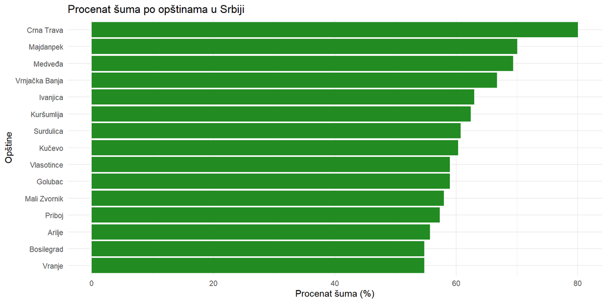

```r
opst |>
  slice_max(p18, n = 15) |> # Sortiranje opština po procentu šuma
  ggplot(aes(y = reorder(Name, p18), x = p18)) +  # Horizontalna os
  geom_col(fill = "forestgreen") +  # Boja stubaca
  labs(
    title = "Procenat šuma po opštinama u Srbiji",
    x = "Procenat šuma (%)",
    y = "Opštine"
  ) +
  theme_minimal()
```

## Horizontalni bar grafikon opštine sa najmanje šume 2018

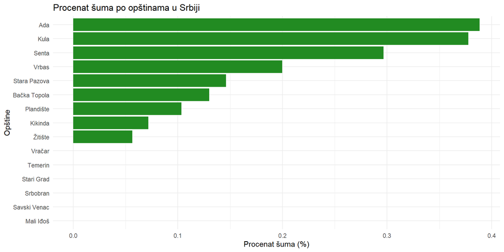

```r
opst |>
  slice_min(p18, n = 15) |> # Sortiranje opština po procentu šuma
  ggplot(aes(y = reorder(Name, p18), x = p18)) +  # Horizontalna os
  geom_col(fill = "forestgreen") +  # Boja stubaca
  labs(
    title = "Procenat šuma po opštinama u Srbiji",
    x = "Procenat šuma (%)",
    y = "Opštine"
  ) +
  theme_minimal()
```

## Horizontalni bar grafikon opštine sa najviše novih šuma 2018-2012

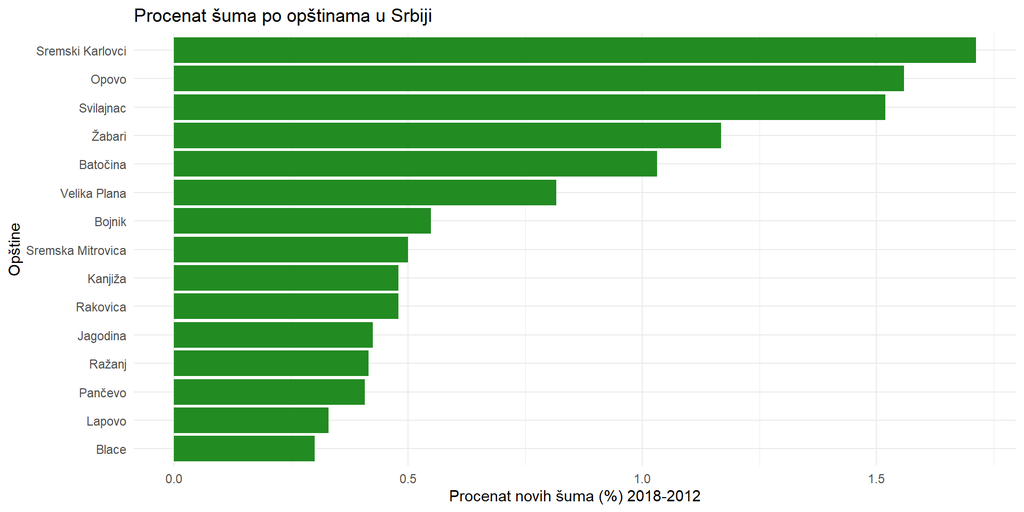

```r
opst |>
  slice_max(razlika_18_12, n = 15) |> # Sortiranje opština po procentu šuma
  ggplot(aes(y = reorder(Name, razlika_18_12), x = razlika_18_12)) +  # Horizontalna os
  geom_col(fill = "forestgreen") +  # Boja stubaca
  labs(
    title = "Procenat šuma po opštinama u Srbiji",
    x = "Procenat novih šuma (%) 2018-2012",
    y = "Opštine"
  ) +
  theme_minimal()
```

## Horizontalni bar grafikon opštine sa najviše posečenih šuma 2018-2012

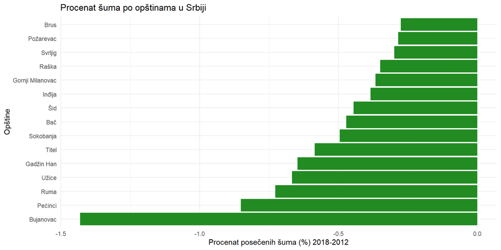

```r
opst |>
  slice_min(razlika_18_12, n = 15) |> # Sortiranje opština po procentu šuma
  ggplot(aes(y = reorder(Name, razlika_18_12), x = razlika_18_12)) +  # Horizontalna os
  geom_col(fill = "forestgreen") +  # Boja stubaca
  labs(
    title = "Procenat šuma po opštinama u Srbiji",
    x = "Procenat posečenih šuma (%) 2018-2012",
    y = "Opštine"
  ) +
  theme_minimal()
```

## Podaci dostupni iz Web servisa

- Tipični veb servisi za prostorne podatke generišu podatke u realnom vremenu i omogućavaju pristup putem API-ja.
- Na primer, podaci iz OpenStreetMap-a mogu se preuzeti u celosti i koristiti lokalno, na primer pomoću GDAL vektorskog drajvera.
- Međutim, korisnici obično žele da dobiju manji podskup podataka ili da ih koriste za određene upite.

## R paketi za upite OpenStreetMap podataka

#### Paket OpenStreetMap

- **Autori**: Fellows i JMapViewer biblioteka (Jan Peter Stotz, 2019)
- Preuzima podatke u obliku rasterskih tajlova
- Obično se koristi kao pozadinska-osnovna karta za vizuelizaciju drugih prostornih elemenata

#### Paket osmdata

- **Autori**: Mark Padgham i saradnici (2017)
- Preuzima vektorske podatke kao tačke, linije ili poligone
- Podaci su u `sf` ili `sp` formatu

#### Paket osmar

- Dostupan iz CRAN arhive
- Vraća vektorske podatke uz dodatne informacije o mrežnoj topologiji
- Koristi `igraph` objekat za predstavljanje povezanosti puteva
- Sadrži funkcije za izračunavanje najkraće rute

## Direktno preuzimanje podataka iz OpenStreetMap bez posredničkih paketa

```r
# Definiši bbox oko GRF (44.805620, 20.475745)
bbox <- paste0("bbox=", 20.470, ",", 44.803, ",", 20.481, ",", 44.808)

# Formiraj URL za preuzimanje podataka sa OpenStreetMap API-ja
osm_url <- paste0("https://www.openstreetmap.org/api/0.6/map?", bbox)

# Preuzmi OSM podatke i sačuvaj ih kao fajl
download.file(osm_url, "data/beograd.osm", method = "auto")

# Provera preuzetog fajla
file.exists("data/beograd.osm")
```

```
[1] TRUE
```

## Konverzija OSM podataka u sf objekat i plot

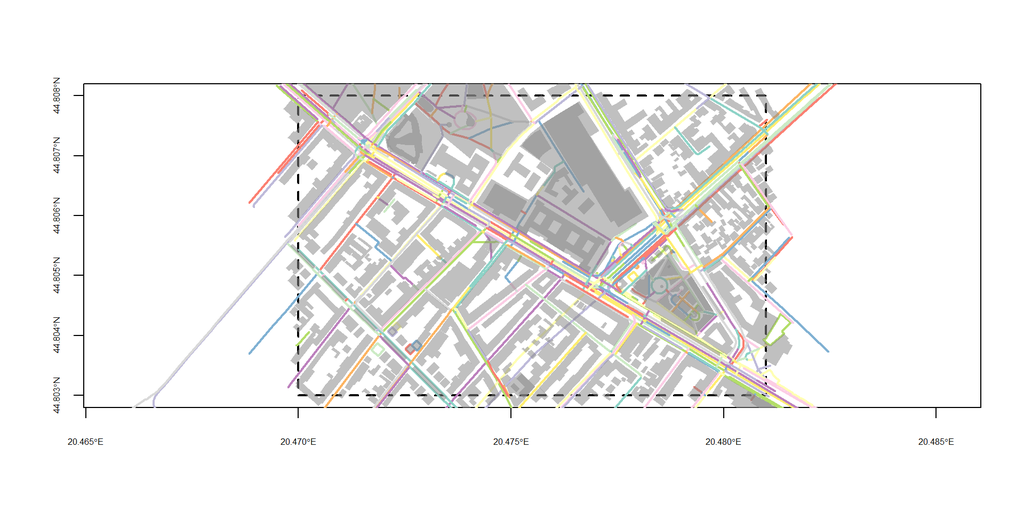

```r
# Učitaj linijske (putevi) i poligonalne (zgrade) podatke iz preuzetog OSM fajla
o <- read_sf("data/beograd.osm", layer = "lines")
p <- read_sf("data/beograd.osm", layer = "multipolygons")
# Definiši bbox za oblast oko Beograda
bbox <- st_bbox(c(xmin = 20.470, ymin = 44.803,
                  xmax = 20.481, ymax = 44.808), crs = 'OGC:CRS84') |>
        st_as_sfc()
# Iscrtavanje bbox-a
plot(bbox, axes = TRUE, lwd = 2, lty = 2, cex.axis = 0.5)
# Dodavanje linijskih objekata (putevi)
plot(o[,1], lwd = 2, add = TRUE)
# Dodavanje poligona objekata (zgrade)
plot(st_geometry(p), border = NA, col = '#88888888', add = TRUE) # objekti sivo
```

## Dobijena kartografska vizualizacija OSM podataka

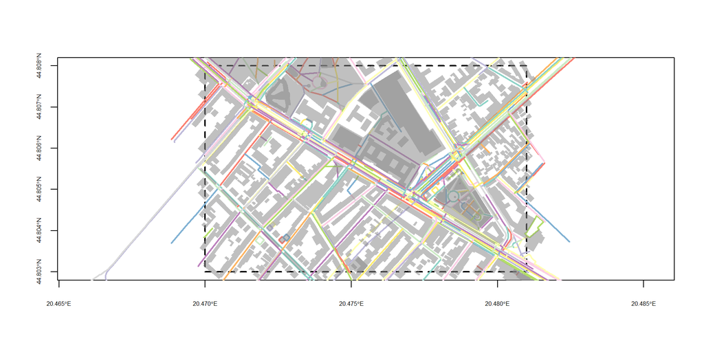

## GeoParquet i GeoArrow

Dva formata namenjena cloud-native analizi dolaze iz Apache projekata **Parquet** i **Arrow**. Obe tehnologije omogućavaju **skladištenje podataka po kolonoma**, što omogućava brzo čitanje pojedinačnih polja za veliki broj zapisa.

#### Osobine

- **Skladištenje geometrije**:
  - U **binarnoj** ili **tekstualnoj** formi
  - Efikasnija struktura sa indeksiranjem podgeometrija
- **Skladištenje CRS-a**: Čuva informacije o koordinatnom referentnom sistemu (CRS)
- **Podrška u GDAL-u**: Dostupno od verzije **3.5**
- **Podrška za kompresiju podataka**

#### Razlike između formata

| Format | Glavna svrha |
| --- | --- |
| **GeoParquet** | Trajno skladištenje |
| **GeoArrow** | Brzi pristup i analiza |

**GeoArrow** može biti korišćen i kao **memorijski** i kao **diskovni format**. Pokazao se efikasan za analize ogromene količine podataka

## `sp` - `sf` poređenje

| how to.. | for `sp` objects | for `sf` objects |
| --- | --- | --- |
| join attributes | `sp::merge()` | `dplyr::*_join()` (also `sf::merge()`) |
| reproject | `spTransform()` | `st_transform()` |
| retrieve (or assign) CRS | `proj4string()` | `st_crs()` |
| count points in polygons | `over()` | `st_within` and `aggregate()` |
| buffer | `rgeos::gBuffer()` (separate package) | `st_buffer()` |
| select by location | [`g*` functions](https://www.rdocumentation.org/packages/rgeos/) from `rgeos` | [st_* geos functions](https://www.rdocumentation.org/packages/sf/topics/geos) in `sf` |

## Literatura

1. Pebesma, E., Bivand, R., 2021. *Spatial Data Science*. CRC Press. https://r-spatial.org/book/
2. Bivand, R., Pebesma, E., Gomez-Rubio, V., 2013. *Applied Spatial Data Analysis with R*. Springer. https://asdar-book.org/
3. Lovelace, R., Nowosad, J., & Muenchow, J. (2019). *Geocomputation with R.* Chapman and Hall/CRC. https://geocompr.robinlovelace.net/
4. Pebesma, E., 2018. Simple Features for R: Standardized Support for Spatial Vector Data. *The R Journal*, 10(1), pp.439-446. https://doi.org/10.32614/RJ-2018-009